# Orders analysis

```python
import numpy as np
import pandas as pd
import datetime
from tqdm import tqdm
pd.options.display.float_format = '{:,.2f}'.format
tqdm.pandas()

import matplotlib.pyplot as plt
import seaborn as sns

# Better plots
sns.set(style="whitegrid")
plt.rcParams["figure.figsize"] = (8, 5)
```

```python
path = r'C:\Users\NGUYENVH1\Downloads\Nguyên Vũ\Phi house'
path_inventory = path + r'\export_detail_inventory_history.xlsx'
path_orders = path + r'\orders housecleaner.xlsx'
```

```python
file_inventory = pd.ExcelFile(path_inventory)
file_orders = pd.ExcelFile(path_orders)
```

```python
inventory = pd.read_excel(file_inventory,sheet_name='DataSheet 1')
orders = pd.read_excel(file_orders,sheet_name='sheet')
```

```python
#Chọn cột có ý nghĩa phân tích
#Check các cột của bảng orders
orders.columns.tolist()

text = 'Return rate'
orders[text].unique()
orders[text].value_counts()

#Tạo longlist và shortlist
longlist = orders[['Full Order ID','Warehouse status','Tracking number','Courier','Fee paid to courier',
        'Status','Shipping status','Assigned seller','Tag','Number of items','Customer','Phone number','Products list',
        'Province ID','Creation time','Day created','Product name','Product ID','Quantity','COD','Shipping note',
        'Internal note','Reconciled COD','COD from courier','Total reconciliation fee','Total price have ship',
        'Total price excluding shipping fee','Status update timeline','Customer orders count'
        ,'Return reason','Region','Quantity (exclude returned quantity)','Order profit','Revenue (before returns)',
          'Delivery attempts', 'Returned revenue', 'Customer phone',
                   'Total order amount before marketplace fee','Return rate']]
shortlist = orders[['Full Order ID','Day created','Warehouse status','Fee paid to courier',
        'Status','Tag','Number of items','Phone number',
        'Product ID','Quantity','COD',
        'Reconciled COD','COD from courier','Total reconciliation fee','Total price have ship',
        'Total price excluding shipping fee','Region','Order profit','Delivery attempts',
                    'Return rate'                   ]]
```

```python
import matplotlib.pyplot as plt
#Hàm A
def plot_pie(df, columns, palette='Set2', figsize=(13, 4)):
    fig, axes = plt.subplots(1, len(columns), figsize=figsize)
    if len(columns) == 1: axes = [axes]
    for ax, column in zip(axes, columns):
        counts = df[column].fillna('Unknown').value_counts()
        total = counts.sum()
        colors = plt.get_cmap(palette)(range(len(counts)))
        wedges, _, _ = ax.pie(counts.values, colors=colors, autopct=lambda pct: str(round(pct * total / 100)) if pct > 0 else '', startangle=90, counterclock=False, pctdistance=0.7, radius=0.8, textprops={'fontsize': 14}, wedgeprops={'edgecolor': 'white', 'linewidth': 1})
        legend_labels = [f'{value}: {count / total:.1%}' for value, count in counts.items()]
        ax.legend(wedges, legend_labels, title=column, loc='center left', bbox_to_anchor=(0.85, 0.5), fontsize=14, frameon=False)
        ax.set_title(f'Phân bố theo {column}', fontsize=14, fontweight='bold')
        ax.axis('equal')
    plt.tight_layout()
    plt.show()
```

```python
#hàm A.2
import pandas as pd

def analyze_pies(df, columns):
    for column in columns:
        s = df[column].fillna('Unknown')
        counts = s.value_counts()
        pct = counts / counts.sum() * 100

        if column == 'Status':
            status = s.astype(str).str.strip().str.lower()
            returned = status.eq('returned').sum()
            returning = status.eq('returning').sum()
            total_return = returned + returning
            print(f'\nStatus:\nTổng hoàn hàng: {total_return}/{len(status)} đơn ({total_return/len(status):.1%}).\nReturned: {returned} đơn ({returned/len(status):.1%}).\nReturning: {returning} đơn ({returning/len(status):.1%}).')

        elif column == 'Fee paid to courier':
            fee = pd.to_numeric(df[column], errors='coerce')
            valid_fee = fee[fee > 0]
            print(f'\nFee paid to courier:\nPhí ship trung bình: {valid_fee.mean():.2f}, tính trên {valid_fee.count()} đơn có phí ship.')

        elif column == 'Quantity':
            top1, top2 = counts.index[0], counts.index[1]
            count1, count2 = counts.iloc[0], counts.iloc[1]
            pct1, pct2 = pct.iloc[0], pct.iloc[1]
            top2_pct = pct.iloc[:2].sum()
            concentration = 'tập trung cao' if pct1 >= 60 else 'tập trung vừa phải' if pct1 >= 40 else 'phân tán'
            print(f'\nQuantity:\nPhân phối {concentration}.\nNhóm {top1} lớn nhất với {count1} đơn ({pct1:.1f}%), tiếp theo là nhóm {top2} với {count2} đơn ({pct2:.1f}%).\nHai nhóm đầu chiếm tổng cộng {top2_pct:.1f}%.')
```

```python
#Hàm B
#Hàm PT số lượng
import matplotlib.pyplot as plt

def plot_hist(df,column,title):

    bins=20
    figsize=(10, 5)
    data = df[column].dropna()
    ax = data.plot(kind='hist',bins=bins,figsize=figsize,edgecolor='black')

    ax.set_xlabel('Return rate')
    ax.set_ylabel('Số lượng ' + title)
    ax.set_title('Phân phối Return rate của các ' + title)

    plt.tight_layout()
    plt.show()

#Hàm tính gain&loss

def plot_profit_by_return_rate(df,return_col='return_rate',profit_col='profit',cod_col='cod', title=''):
    bins=20
    # Loại bỏ dòng thiếu dữ liệu
    data = df[[return_col, profit_col,cod_col]].dropna().copy()
    # Chia return_rate thành các khoảng
    data['return_rate_bin'] = pd.cut(data[return_col],bins=bins)
    # Tính tổng profit trong từng khoảng return_rate
    summary_by_bin = (data.groupby('return_rate_bin', observed=False)[[profit_col, cod_col]].sum())
    # Lấy trung điểm mỗi khoảng làm giá trị trục x
    x = [interval.mid for interval in summary_by_bin.index]
    # Xác định độ rộng của cả nhóm cột
    bin_width = (summary_by_bin.index[0].right- summary_by_bin.index[0].left)
    bar_width = bin_width * 0.4
    # Vẽ biểu đồ
    fig, ax = plt.subplots(figsize=(12, 5))
    ax.bar([value - bar_width / 2 for value in x],summary_by_bin[profit_col],width=bar_width,label='Tổng profit',edgecolor='black')
    ax.bar([value + bar_width / 2 for value in x],summary_by_bin[cod_col],width=bar_width,label='Tổng COD',edgecolor='black')
    ax.axhline(y=0,color='black',linewidth=1)
    ax.set_xlabel('Return rate')
    ax.set_ylabel('Tổng giá trị')
    ax.set_title('Tổng profit và COD theo Return rate'+ (f' của {title}' if title else ''))
    ax.legend()
    plt.tight_layout()
    plt.show()
    #return summary_by_bin
```

```python
#tag là và status là tình trạng cancelled, returned, success
#cần xem quantity và number of items có khác nhau k
#shipping note là trạng thái telesale
#check cod vs reconcile cod, 'COD from courier'
```

## A. PHÂN TÍCH CƠ BẢN

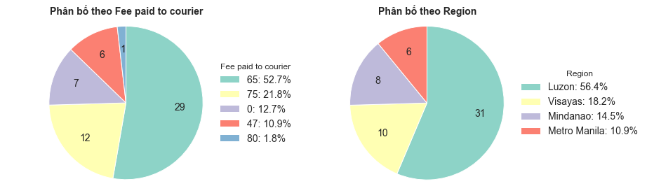

```python
plot_pie(shortlist, ['Fee paid to courier', 'Region'], palette='Set3')
```

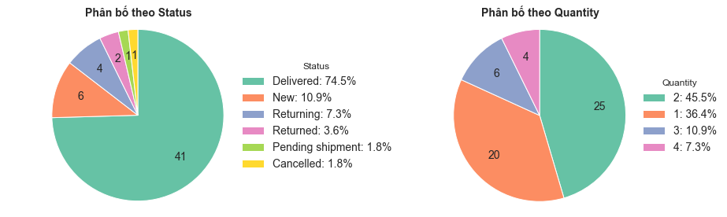

```python
plot_pie(shortlist, ['Status', 'Quantity'], palette='Set2')
```

```python
analyze_pies(shortlist, ['Fee paid to courier', 'Region', 'Status', 'Quantity'])
```

```
Fee paid to courier:
Phí ship trung bình: 65.56, tính trên 48 đơn có phí ship.

Status:
Tổng hoàn hàng: 6/55 đơn (10.9%).
Returned: 2 đơn (3.6%).
Returning: 4 đơn (7.3%).

Quantity:
Phân phối tập trung vừa phải.
Nhóm 2 lớn nhất với 25 đơn (45.5%), tiếp theo là nhóm 1 với 20 đơn (36.4%).
Hai nhóm đầu chiếm tổng cộng 81.8%.
```

## B. RETURN RATE ANALYSIS

```python
orders_by_phone = (shortlist.groupby('Phone number', as_index=False).agg(qty=('Quantity', 'sum'),cod=('COD', 'sum'),profit=('Order profit', 'sum'),orders=('Full Order ID', 'nunique'),return_rate=('Return rate', 'first'),ship=('Total reconciliation fee', 'sum')))
status = (shortlist.pivot_table(index='Phone number',columns='Status',values='Full Order ID',aggfunc='nunique',fill_value=0).rename(columns={'Cancelled': 'cancelled','Delivered': 'delivered','Returned': 'returned'}).reset_index())
orders_by_phone = (orders_by_phone.merge(status, on='Phone number', how='left').sort_values('profit', ascending=False).reset_index(drop=True))

orders_by_phone['profit_rank'] = (orders_by_phone['profit'].rank(method='dense', ascending=False).astype(int))
orders_by_phone = orders_by_phone.sort_values(['profit_rank', 'Phone number']).reset_index(drop=True)
orders_by_phone.return_rate= pd.to_numeric(orders_by_phone['return_rate'].astype(str).str.rstrip('%'),errors='coerce') / 100

user_profit = orders_by_phone[orders_by_phone['profit']>0]
user_loss = orders_by_phone[orders_by_phone['profit']<0]
user_loss['return_rate'].value_counts().sort_index(ascending=False)
```

### 0.1 Phân tích số lượng: Với các khách hàng mang lại lợi nhuận

```python
#plot_hist(user_profit,'return_rate','KH có profit dương')
```

### 0.2 Phân tích số lượng: Với các khách hàng gây lỗ

```python
#plot_hist(user_loss,'return_rate','KH có profit âm')
```

Comment: Với lô hàng này chỉ có 6 khách hàng return, phân bố khá đều. 50% rơi vào return rate >=60%, 50% rơi vào <60%.

### 1. Phân tích lãi lỗ theo nhóm return rate

Tính toán với mỗi nhóm return rate thì lãi hay lỗ. Các nhóm return rate mà gây lỗ thì có tể xem xét cắt ngưỡng.

Lưu ý: data trên chart mới chỉ tính đến chi phí giao hàng, chưa tính đến các chi phí còn lại.

#### Expense components = shipping fee + ads + cogs + cod fee*110% + sale commissions (if any)

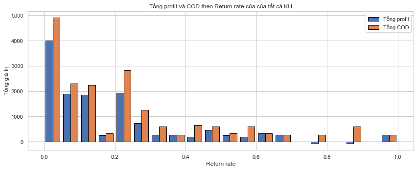

```python
plot_profit_by_return_rate(orders_by_phone,return_col='return_rate',profit_col='profit', title='của tất cả KH')
```

### 2. Phân tích loss amount: Với các khách hàng gây lỗ

Tính toán với mỗi khách hàng gây lỗ thì lỗ bao nhiêu.

Thường với data hiện tại (trên POS) thì: loss = shipping fee của đơn hàng đó.

#### Thực tế: loss = shipping fee + phí chạy ads

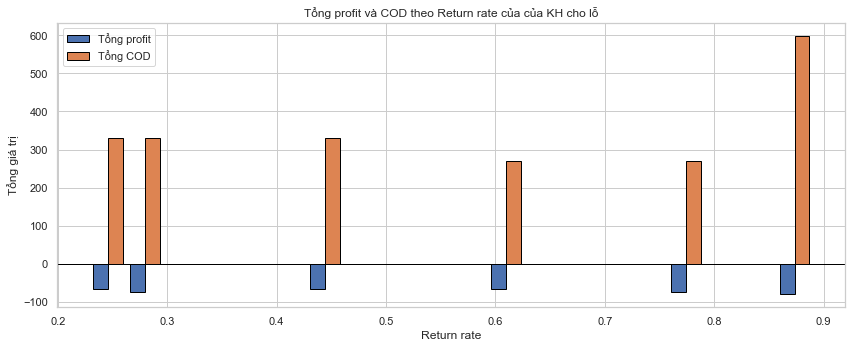

```python
plot_profit_by_return_rate(user_loss,return_col='return_rate',profit_col='profit',cod_col='cod', title='của KH cho lỗ')
```

### 3. Phân tích gain amount: Với các khách cho lợi nhuận

Tính toán với mỗi khách hàng cho lãi thì lãi bao nhiêu.

Thường với data hiện tại (trên POS) thì: gain = COD - shipping fee.

#### Thực tế: gain = COD - shipping fee - ads - cogs - cod fee*110% - sale commissions (if any)

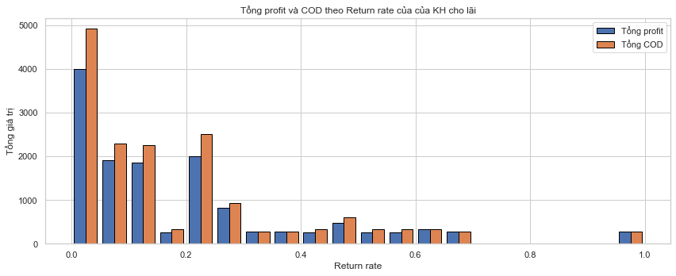

```python
plot_profit_by_return_rate(user_profit,return_col='return_rate',profit_col='profit', title='của KH cho lãi')
```